# Actividad 2.4 Detección de datos influyentes

Rey Iván De La Fuente Chávez

2026-08-25

En esta actividad se ajusta un modelo de regresión lineal para explicar la **Resistencia** a partir de las demás variables. Posteriormente se identifican datos atípicos e influyentes y se compara el modelo original con un modelo sin estas observaciones.

```r
# Paquetes necesarios
library(car)
```

```r
library(ggplot2)

# Cargar datos
datos <- read.csv('C:\\Users\\reyiv\\Downloads\\datosRes-1.csv')

# Revisar la base
head(datos)
```

```
##   Resistencia Longitud Altura.matriz Altura.poste Altura.amarre
## 1        9.95        2            50            1             1
## 2       24.45        8           110            1             1
## 3       31.75       11           120            2             1
## 4       35.00       10           550            2             2
## 5       25.02        8           295            1             1
## 6       16.86        4           200            1             1
```

```r
names(datos)
```

```
## [1] "Resistencia"   "Longitud"      "Altura.matriz" "Altura.poste"
## [5] "Altura.amarre"
```

# 1. Selección de variables por pasos

Primero se construye el modelo completo utilizando todas las variables predictoras.

```r
modelo_completo <- lm(
  Resistencia ~ Longitud + Altura.matriz + Altura.poste + Altura.amarre,
  data = datos
)

summary(modelo_completo)
```

```
##
## Call:
## lm(formula = Resistencia ~ Longitud + Altura.matriz + Altura.poste +
##     Altura.amarre, data = datos)
##
## Residuals:
##     Min      1Q  Median      3Q     Max
## -3.2818 -1.2098 -0.0752  1.2279  3.0588
##
## Coefficients:
##               Estimate Std. Error t value Pr(>|t|)
## (Intercept)   1.068134   0.927733   1.151  0.26317
## Longitud      2.484232   0.110073  22.569 1.06e-15 ***
## Altura.matriz 0.008554   0.002359   3.626  0.00168 **
## Altura.poste  0.622369   0.811020   0.767  0.45181
## Altura.amarre 2.293924   0.748549   3.064  0.00612 **
## ---
## Signif. codes:  0 '***' 0.001 '**' 0.01 '*' 0.05 '.' 0.1 ' ' 1
##
## Residual standard error: 1.755 on 20 degrees of freedom
## Multiple R-squared:  0.9899, Adjusted R-squared:  0.9879
## F-statistic: 490.6 on 4 and 20 DF,  p-value: < 2.2e-16
```

## 1.1 Selección mediante AIC

Se utiliza el método por pasos para encontrar un modelo con buen ajuste sin incluir variables innecesarias.

```r
modelo_AIC <- step(
  modelo_completo,
  direction = "both",
  trace = 1
)
```

```
## Start:  AIC=32.54
## Resistencia ~ Longitud + Altura.matriz + Altura.poste + Altura.amarre
##
##                 Df Sum of Sq     RSS     AIC
## - Altura.poste   1      1.81   63.41  31.269
## <none>                         61.60  32.543
## - Altura.amarre  1     28.92   90.52  40.167
## - Altura.matriz  1     40.50  102.10  43.176
## - Longitud       1   1568.75 1630.34 112.442
##
## Step:  AIC=31.27
## Resistencia ~ Longitud + Altura.matriz + Altura.amarre
##
##                 Df Sum of Sq     RSS     AIC
## <none>                         63.41  31.269
## + Altura.poste   1      1.81   61.60  32.543
## - Altura.matriz  1     40.21  103.62  41.546
## - Altura.amarre  1     51.76  115.17  44.189
## - Longitud       1   2552.49 2615.90 122.262
```

```r
summary(modelo_AIC)
```

```
##
## Call:
## lm(formula = Resistencia ~ Longitud + Altura.matriz + Altura.amarre,
##     data = datos)
##
## Residuals:
##     Min      1Q  Median      3Q     Max
## -3.2828 -1.1230  0.1207  1.0497  3.1978
##
## Coefficients:
##               Estimate Std. Error t value Pr(>|t|)
## (Intercept)   1.367068   0.833704   1.640 0.115952
## Longitud      2.534919   0.087187  29.074  < 2e-16 ***
## Altura.matriz 0.008522   0.002335   3.649 0.001498 **
## Altura.amarre 2.599278   0.627791   4.140 0.000465 ***
## ---
## Signif. codes:  0 '***' 0.001 '**' 0.01 '*' 0.05 '.' 0.1 ' ' 1
##
## Residual standard error: 1.738 on 21 degrees of freedom
## Multiple R-squared:  0.9896, Adjusted R-squared:  0.9881
## F-statistic:   667 on 3 and 21 DF,  p-value: < 2.2e-16
```

```r
formula(modelo_AIC)
```

```
## Resistencia ~ Longitud + Altura.matriz + Altura.amarre
```

El criterio AIC elimina `Altura.poste` y conserva `Longitud`, `Altura.matriz` y `Altura.amarre`.

## 1.2 Selección mediante BIC

También se realiza la selección mediante BIC, que penaliza más la inclusión de variables adicionales.

```r
n <- nrow(datos)

modelo_BIC <- step(
  modelo_completo,
  direction = "both",
  trace = 1,
  k = log(n)
)
```

```
## Start:  AIC=38.64
## Resistencia ~ Longitud + Altura.matriz + Altura.poste + Altura.amarre
##
##                 Df Sum of Sq     RSS     AIC
## - Altura.poste   1      1.81   63.41  36.144
## <none>                         61.60  38.638
## - Altura.amarre  1     28.92   90.52  45.043
## - Altura.matriz  1     40.50  102.10  48.052
## - Longitud       1   1568.75 1630.34 117.317
##
## Step:  AIC=36.14
## Resistencia ~ Longitud + Altura.matriz + Altura.amarre
##
##                 Df Sum of Sq     RSS     AIC
## <none>                         63.41  36.144
## + Altura.poste   1      1.81   61.60  38.638
## - Altura.matriz  1     40.21  103.62  45.203
## - Altura.amarre  1     51.76  115.17  47.846
## - Longitud       1   2552.49 2615.90 125.919
```

```r
summary(modelo_BIC)
```

```
##
## Call:
## lm(formula = Resistencia ~ Longitud + Altura.matriz + Altura.amarre,
##     data = datos)
##
## Residuals:
##     Min      1Q  Median      3Q     Max
## -3.2828 -1.1230  0.1207  1.0497  3.1978
##
## Coefficients:
##               Estimate Std. Error t value Pr(>|t|)
## (Intercept)   1.367068   0.833704   1.640 0.115952
## Longitud      2.534919   0.087187  29.074  < 2e-16 ***
## Altura.matriz 0.008522   0.002335   3.649 0.001498 **
## Altura.amarre 2.599278   0.627791   4.140 0.000465 ***
## ---
## Signif. codes:  0 '***' 0.001 '**' 0.01 '*' 0.05 '.' 0.1 ' ' 1
##
## Residual standard error: 1.738 on 21 degrees of freedom
## Multiple R-squared:  0.9896, Adjusted R-squared:  0.9881
## F-statistic:   667 on 3 and 21 DF,  p-value: < 2.2e-16
```

```r
formula(modelo_BIC)
```

```
## Resistencia ~ Longitud + Altura.matriz + Altura.amarre
```

AIC y BIC seleccionan las mismas tres variables, por lo que existe consistencia entre ambos criterios.

Para continuar se utilizará el modelo obtenido mediante AIC.

```r
modelo <- modelo_AIC
```

# 2. Datos atípicos

## 2.1 Residuos estandarizados

Los residuos estandarizados permiten identificar observaciones cuyo error es mayor al esperado. Se consideran posibles datos atípicos aquellos con valor absoluto mayor a 2.

```r
rstandard_val <- rstandard(modelo)

# Observaciones con |residuo estandarizado| > 2
which(abs(rstandard_val) > 2)
```

```
##  9 15
##  9 15
```

Las observaciones **9 y 15** presentan residuos estandarizados mayores a 2 en valor absoluto, por lo que pueden considerarse posibles datos atípicos.

## 2.2 Residuos studentizados

Se utiliza un criterio más extremo considerando residuos studentizados mayores a 3 en valor absoluto.

```r
rstudent_val <- rstudent(modelo)

# Observaciones con |residuo studentizado| > 3
which(abs(rstudent_val) > 3)
```

```
## named integer(0)
```

No se encontraron observaciones con residuos studentizados mayores a 3, por lo que no existen datos extremadamente atípicos bajo este criterio.

# 3. Datos influyentes

## 3.1 Leverage

El leverage permite identificar observaciones con valores poco comunes en las variables predictoras.

Se utilizará como límite:

$$\frac{2p}{n}$$

donde $p$ es el número de parámetros del modelo y $n$ el número de observaciones.

```r
hat <- hatvalues(modelo)

p <- length(coef(modelo))
limite_hat <- 2 * p / nrow(datos)

limite_hat
```

```
## [1] 0.32
```

```r
# Observaciones con leverage alto
which(hat > limite_hat)
```

```
## 17
## 17
```

La observación **17** presenta leverage alto, por lo que sus valores en las variables predictoras son diferentes a los del resto y podría afectar el modelo.

## 3.2 Distancia de Cook

La distancia de Cook mide qué tanto puede cambiar el modelo por la presencia de una observación.

Se utiliza como referencia:

$$\frac{4}{n}$$

```r
cooks <- cooks.distance(modelo)

limite_cook <- 4 / nrow(datos)

limite_cook
```

```
## [1] 0.16
```

```r
# Observaciones potencialmente influyentes
which(cooks > limite_cook)
```

```
##  9 11 15 17
##  9 11 15 17
```

Las observaciones **9, 11, 15 y 17** superan el límite de Cook y se consideran observaciones influyentes.

# 4. Resumen de resultados

Se reúnen los indicadores anteriores en una sola tabla.

```r
tabla <- data.frame(
  Observacion = 1:nrow(datos),
  Residual = residuals(modelo),
  Rstandard = rstandard_val,
  Rstudent = rstudent_val,
  Hat = hat,
  Cooks = cooks
)

tabla
```

```
##    Observacion    Residual   Rstandard    Rstudent        Hat        Cooks
## 1            1  0.48774064  0.30995789  0.30318224 0.17997067 5.271300e-03
## 2            2 -0.73306293 -0.44841839 -0.43972181 0.11494030 6.528398e-03
## 3            3 -1.12303432 -0.70704561 -0.69836840 0.16449688 2.460620e-02
## 4            4 -1.60164669 -0.97259115 -0.97127920 0.10188969 2.682880e-02
## 5            5 -1.73954411 -1.03667630 -1.03861768 0.06751594 1.945321e-02
## 6            6  1.04967520  0.62805855  0.61876125 0.07494729 7.989686e-03
## 7            7  2.14824669  1.31710547  1.34198733 0.11898344 5.857113e-02
## 8            8  0.12069760  0.07663099  0.07479465 0.17842872 3.188368e-04
## 9            9 -3.28276646 -2.03067946 -2.21063596 0.13452586 1.602413e-01
## 10          10  0.69784830  0.41597748  0.40763536 0.06794985 3.153762e-03
## 11          11 -3.13616456 -1.96463341 -2.12221013 0.15609899 1.784891e-01
## 12          12 -0.85833744 -0.50828735 -0.49911740 0.05560348 3.802824e-03
## 13          13 -1.89468571 -1.21298733 -1.22753822 0.19198635 8.739854e-02
## 14          14 -0.44393051 -0.27131869 -0.26524523 0.11340056 2.353896e-03
## 15          15  3.19779005  2.06875195  2.26256901 0.20870226 2.821916e-01
## 16          16  0.37537123  0.22750728  0.22229849 0.09845327 1.413099e-03
## 17          17  1.42453490  1.07912706  1.08359296 0.42289094 2.133318e-01
## 18          18 -1.18635375 -0.82003000 -0.81339633 0.30685227 7.442229e-02
## 19          19  1.01284607  0.66091424  0.65180073 0.22222579 3.120119e-02
## 20          20 -0.12978438 -0.08090377 -0.07896631 0.14775554 2.836986e-04
## 21          21  0.41863238  0.28009197  0.27385378 0.26018831 6.897757e-03
## 22          22  0.05042417  0.03204011  0.03126871 0.17974960 5.624053e-05
## 23          23  1.94306140  1.27689138  1.29750549 0.23312954 1.239148e-01
## 24          24  2.10198973  1.28159757  1.30269262 0.10912925 5.030021e-02
## 25          25  1.10045250  0.66393145  0.65483998 0.09018521 1.092368e-02
```

Para facilitar la revisión, se muestran solamente las observaciones que cumplen al menos uno de los criterios.

```r
tabla$Atipico_standard <- abs(tabla$Rstandard) > 2
tabla$Atipico_student <- abs(tabla$Rstudent) > 3
tabla$Leverage_alto <- tabla$Hat > limite_hat # 0.32
tabla$Cook_alto <- tabla$Cooks > limite_cook # 0.16

tabla_importantes <- tabla[
  tabla$Atipico_standard |
  tabla$Atipico_student |
  tabla$Leverage_alto |
  tabla$Cook_alto,
]

tabla_importantes
```

```
##    Observacion  Residual Rstandard  Rstudent       Hat     Cooks
## 9            9 -3.282766 -2.030679 -2.210636 0.1345259 0.1602413
## 11          11 -3.136165 -1.964633 -2.122210 0.1560990 0.1784891
## 15          15  3.197790  2.068752  2.262569 0.2087023 0.2821916
## 17          17  1.424535  1.079127  1.083593 0.4228909 0.2133318
##    Atipico_standard Atipico_student Leverage_alto Cook_alto
## 9              TRUE           FALSE         FALSE      TRUE
## 11            FALSE           FALSE         FALSE      TRUE
## 15             TRUE           FALSE         FALSE      TRUE
## 17            FALSE           FALSE          TRUE      TRUE
```

Las observaciones **9, 11, 15 y 17** requieren mayor atención. Las observaciones 9 y 15 son además posibles datos atípicos, mientras que la 17 presenta leverage alto.

# 5. Gráficos complementarios

## 5.1 Variable dependiente contra las variables predictoras

Los gráficos de variable agregada muestran la relación entre cada predictor y la resistencia considerando el efecto de las demás variables.

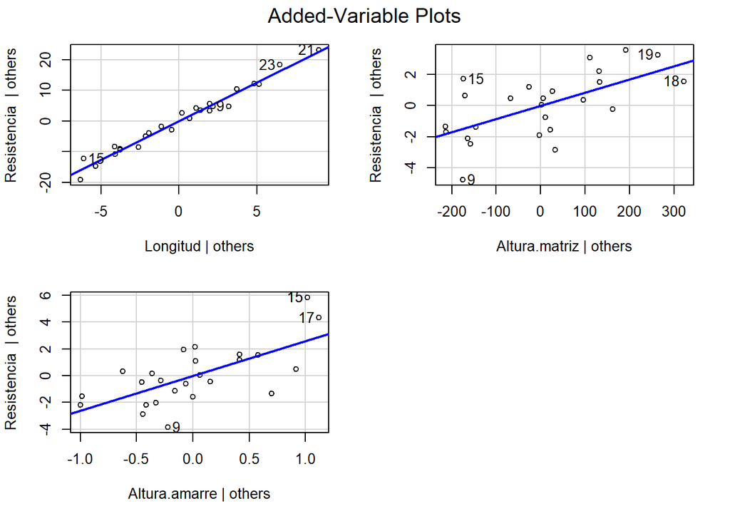

```r
avPlots(modelo)
```

Las variables seleccionadas presentan una relación con la resistencia. La relación con `Longitud` es especialmente marcada.

## 5.2 Residuos studentizados absolutos

Se grafican los residuos studentizados absolutos. La línea horizontal representa el límite de 3.

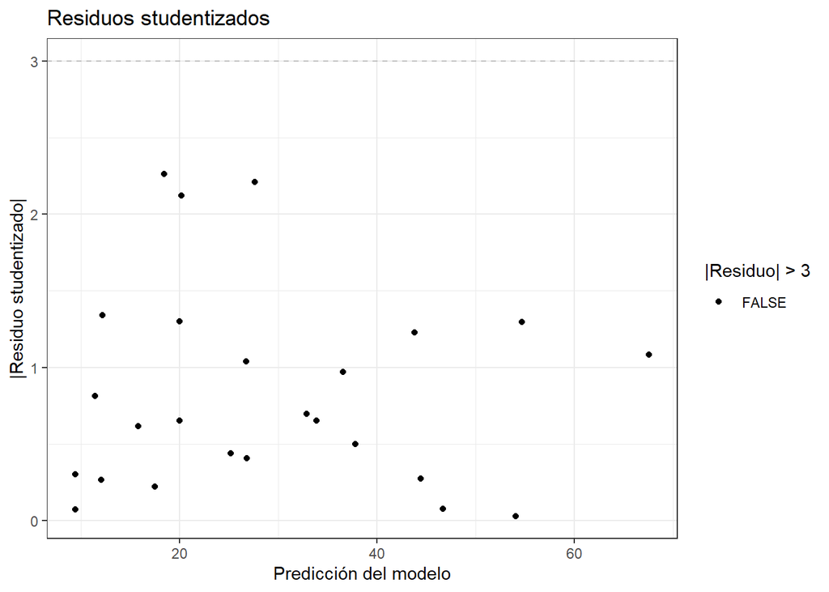

```r
grafica_residuos <- data.frame(
  Prediccion = predict(modelo),
  Rstudent = rstudent_val
)

ggplot(
  grafica_residuos,
  aes(x = Prediccion, y = abs(Rstudent))
) +
  geom_hline(
    yintercept = 3,
    color = "grey",
    linetype = "dashed"
  ) +
  geom_point(
    aes(color = abs(Rstudent) > 3)
  ) +
  scale_color_manual(
    values = c("FALSE" = "black", "TRUE" = "red")
  ) +
  labs(
    title = "Residuos studentizados",
    x = "Predicción del modelo",
    y = "|Residuo studentizado|",
    color = "|Residuo| > 3"
  ) +
  theme_bw()
```

Ninguna observación supera el límite de 3, por lo que no se identifican valores extremadamente atípicos mediante este criterio.

## 5.3 Gráfico de influencia

El gráfico de influencia permite observar conjuntamente los residuos, leverage y distancia de Cook.

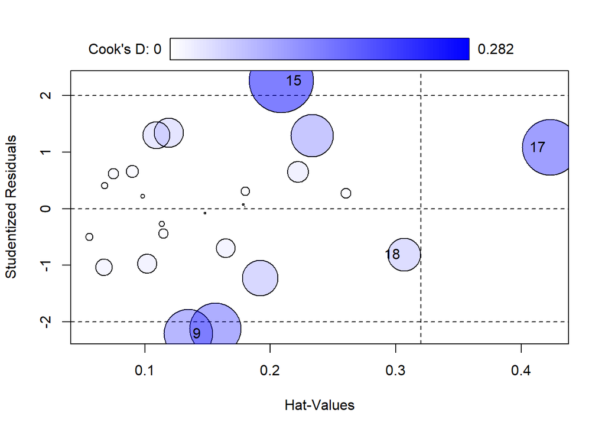

```
##       StudRes       Hat      CookD
## 9  -2.2106360 0.1345259 0.16024130
## 15  2.2625690 0.2087023 0.28219160
## 17  1.0835930 0.4228909 0.21333184
## 18 -0.8133963 0.3068523 0.07442229
```

```r
influencePlot(
  modelo,
  id = TRUE
)
```

El gráfico confirma que algunas observaciones tienen mayor influencia sobre el modelo, especialmente las detectadas anteriormente mediante leverage y distancia de Cook.

# 6. Ajustes al modelo

Como existen observaciones influyentes, se ajustará nuevamente el modelo eliminando las observaciones identificadas mediante la distancia de Cook.

```r
influyentes <- which(cooks > limite_cook)

influyentes
```

```
##  9 11 15 17
##  9 11 15 17
```

```r
# Base sin las observaciones influyentes
datos_sin_influyentes <- datos[-influyentes, ]

# Mismo modelo, pero sin esas observaciones
modelo_sin_influyentes <- lm(
  formula(modelo),
  data = datos_sin_influyentes
)

summary(modelo_sin_influyentes)
```

```
##
## Call:
## lm(formula = formula(modelo), data = datos_sin_influyentes)
##
## Residuals:
##      Min       1Q   Median       3Q      Max
## -2.11283 -0.90273  0.05639  0.80568  1.97559
##
## Coefficients:
##               Estimate Std. Error t value Pr(>|t|)
## (Intercept)   2.130936   0.708178   3.009 0.007901 **
## Longitud      2.572829   0.072816  35.333  < 2e-16 ***
## Altura.matriz 0.008857   0.001815   4.880 0.000141 ***
## Altura.amarre 1.806457   0.604494   2.988 0.008257 **
## ---
## Signif. codes:  0 '***' 0.001 '**' 0.01 '*' 0.05 '.' 0.1 ' ' 1
##
## Residual standard error: 1.262 on 17 degrees of freedom
## Multiple R-squared:  0.9937, Adjusted R-squared:  0.9925
## F-statistic:   889 on 3 and 17 DF,  p-value: < 2.2e-16
```

Se eliminaron las observaciones **9, 11, 15 y 17** para analizar cuánto cambia el comportamiento del modelo.

## 6.1 Variabilidad explicada

Se comparan $R^2$ y $R^2$ ajustado.

```r
R2_original <- summary(modelo)$r.squared
R2_nuevo <- summary(modelo_sin_influyentes)$r.squared

R2_ajustado_original <- summary(modelo)$adj.r.squared
R2_ajustado_nuevo <- summary(modelo_sin_influyentes)$adj.r.squared

R2_original
```

```
## [1] 0.9896149
```

```r
R2_nuevo
```

```
## [1] 0.9936661
```

```r
R2_ajustado_original
```

```
## [1] 0.9881313
```

```r
R2_ajustado_nuevo
```

```
## [1] 0.9925484
```

El $R^2$ aumenta de aproximadamente **0.9896 a 0.9937**. Por lo tanto, después de eliminar las observaciones influyentes, el modelo explica ligeramente más variabilidad de la resistencia.

## 6.2 Significancia global de los modelos

Se calcula el p-valor de la prueba F para ambos modelos.

```r
# Modelo original
f_original <- summary(modelo)$fstatistic

p_original <- pf(
  f_original[1],
  f_original[2],
  f_original[3],
  lower.tail = FALSE
)

# Modelo sin datos influyentes
f_nuevo <- summary(modelo_sin_influyentes)$fstatistic

p_nuevo <- pf(
  f_nuevo[1],
  f_nuevo[2],
  f_nuevo[3],
  lower.tail = FALSE
)

p_original
```

```
##        value
## 5.601655e-21
```

```r
p_nuevo
```

```
##        value
## 7.055826e-19
```

Los dos p-valores son mucho menores a 0.05, por lo que ambos modelos son estadísticamente significativos.

## 6.3 Cumplimiento de los supuestos

Primero se revisan los gráficos de diagnóstico del modelo original.

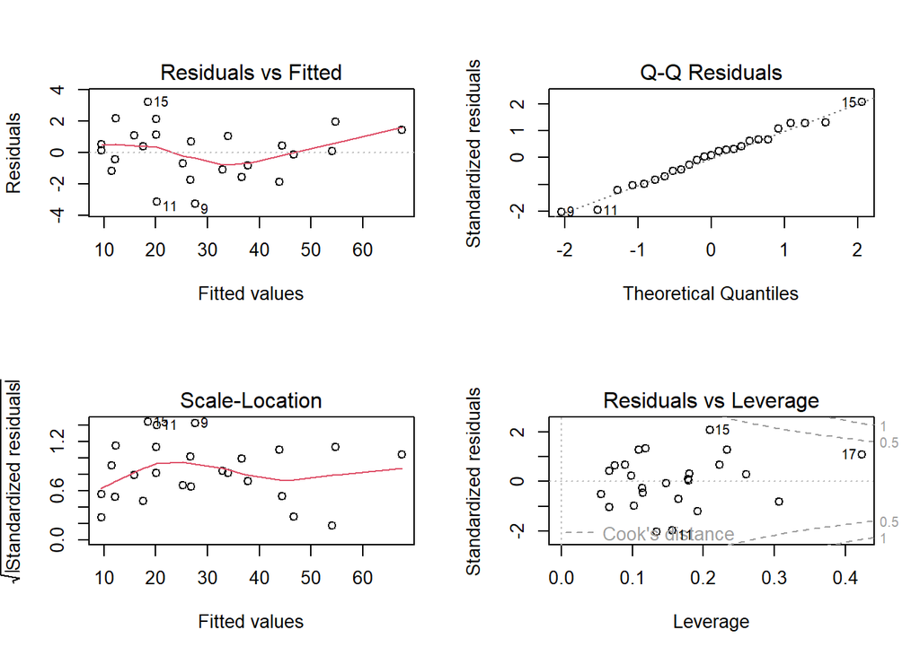

```r
par(mfrow = c(2, 2))

plot(modelo)
```

```r
par(mfrow = c(1, 1))
```

En el modelo original los residuos siguen aproximadamente una distribución normal, pero se observan algunas desviaciones y observaciones con mayor influencia. También existe una ligera curvatura en los residuos.

Ahora se revisa el modelo sin las observaciones influyentes.

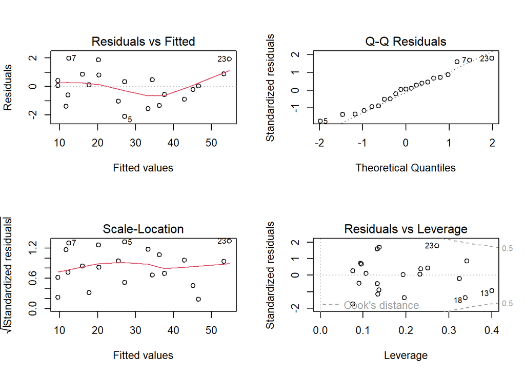

```r
par(mfrow = c(2, 2))

plot(modelo_sin_influyentes)
```

```r
par(mfrow = c(1, 1))
```

Al eliminar las observaciones influyentes, los residuos presentan un comportamiento más estable y el gráfico Q-Q se mantiene cercano a una línea recta. Existe todavía una ligera curvatura, pero no se observa una violación fuerte de los supuestos.

## 6.4 AIC y BIC

Finalmente se reportan AIC y BIC para ambos modelos.

```r
AIC_original <- AIC(modelo)
AIC_nuevo <- AIC(modelo_sin_influyentes)

BIC_original <- BIC(modelo)
BIC_nuevo <- BIC(modelo_sin_influyentes)

AIC_original
```

```
## [1] 104.2158
```

```r
AIC_nuevo
```

```
## [1] 74.94356
```

```r
BIC_original
```

```
## [1] 110.3102
```

```r
BIC_nuevo
```

```
## [1] 80.16617
```

El modelo sin observaciones influyentes presenta valores menores de AIC y BIC. Sin embargo, los modelos utilizan diferente número de observaciones.

## 6.5 Tabla comparativa

Se resumen los principales indicadores de ambos modelos.

```r
comparacion <- data.frame(
  Modelo = c("Original", "Sin influyentes"),
  R2 = c(R2_original, R2_nuevo),
  R2_ajustado = c(R2_ajustado_original, R2_ajustado_nuevo),
  P_valor = c(p_original, p_nuevo),
  AIC = c(AIC_original, AIC_nuevo),
  BIC = c(BIC_original, BIC_nuevo)
)

comparacion
```

```
##            Modelo        R2 R2_ajustado      P_valor       AIC       BIC
## 1        Original 0.9896149   0.9881313 5.601655e-21 104.21584 110.31022
## 2 Sin influyentes 0.9936661   0.9925484 7.055826e-19  74.94356  80.16617
```

El modelo sin observaciones influyentes presenta un $R^2$ ligeramente mayor y residuos más estables. Ambos modelos son estadísticamente significativos.

# 7. Conclusiones

La selección por pasos mediante AIC y BIC produjo el mismo modelo, compuesto por `Longitud`, `Altura.matriz` y `Altura.amarre`. La variable `Altura.poste` fue eliminada durante la selección.

Se identificaron las observaciones **9, 11, 15 y 17** como influyentes mediante la distancia de Cook. Al eliminarlas, el $R^2$ aumentó de aproximadamente **98.96% a 99.37%** y los residuos mostraron un comportamiento más estable.

Por lo tanto, para esta actividad, el modelo sin las observaciones influyentes presenta un ajuste ligeramente mejor. Sin embargo, en una aplicación real estas observaciones deberían revisarse antes de eliminarlas definitivamente.